# Quasar

Lovdip Singh

08/01/2021

## Goal of study

To find the ‘best’ model to fit astronomical data associated with measuring quasars (RFWidth).

## Read in data

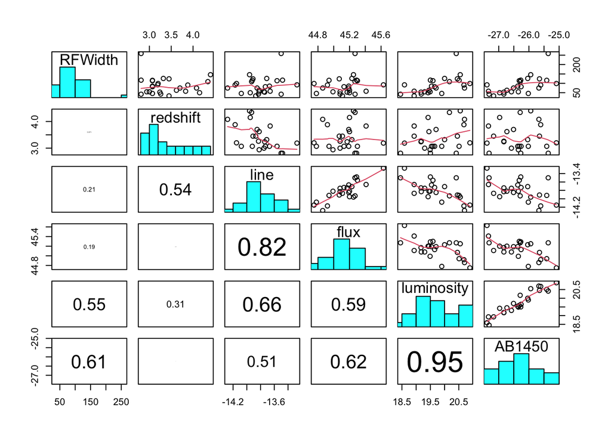

```r
quasar.df <- read.csv('quasar.csv')

pairs20x(quasar.df)
```

Logging `RFWidth` is appropriate as it appears to be right skewed from the histogram. Also there appears to be increasing variability when plotted against other variables.

Not all variables may be of use as some have little to no relationship with `RFWidth` and most other variables, for example `redshift`. Also some variables do a similar job in explaining `RFWidth` as other variables.

## Model fitting

```r
quasar.fit <- lm(log(RFWidth)~., data=quasar.df)

library(MuMIn)
options(na.action = "na.fail")
all.fits <- dredge(quasar.fit)
```

```
## Fixed term is "(Intercept)"
```

```r
# 5 best fitting models
all.fits[1:5,]
```

```
## Global model call: lm(formula = log(RFWidth) ~ ., data = quasar.df)
## ---
## Model selection table
##    (Intrc)    AB145   flux  line  lmnst    rdshf df logLik   AICc delta weight
## 15 -29.800          0.8136 1.508 0.9257           5 91.949 -170.7  0.00  0.677
## 31 -35.260          0.9080 1.415 0.9260 -0.02622  6 92.229 -167.8  2.95  0.155
## 16 -31.520  0.03484 0.8700 1.452 0.8908           6 91.964 -167.3  3.48  0.119
## 14  -4.925 -0.50170        2.326 1.4290           5 88.697 -164.2  6.50  0.026
## 32 -33.960 -0.04002 0.8549 1.469 0.9662 -0.02948  7 92.246 -163.9  6.84  0.022
## Models ranked by AICc(x)
```

AICc is a more appropriate measure of model adequacy than AIC for this data as the sample size is quite low (25). Furthermore, $n / K < 40$ where n is the number of observations and K is the number of parameters, this is true for this case, which makes AICc appropriate (Burnham & Anderson 2002).

The best model is slightly better at supporting the data than the 2nd and 3rd models, as the AICc difference is between 2-4, and is considerably better than the 4th and 5th models (AICc difference between 4-10).

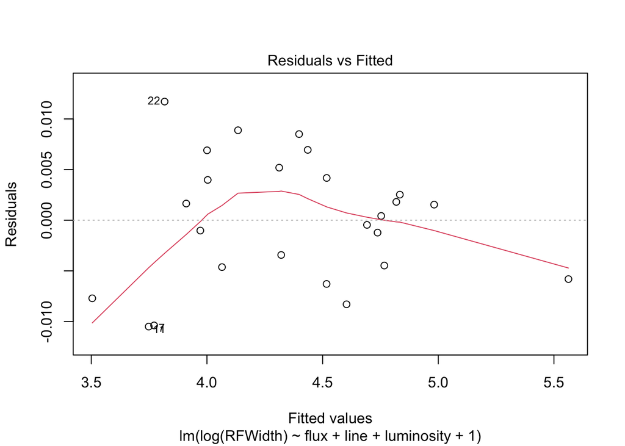

```r
quasar.fit <-  get.models(all.fits, 1)[[1]]

plot(quasar.fit, which=1)
```

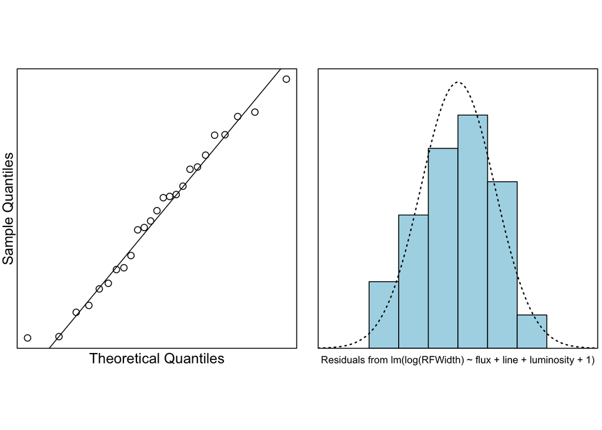

```r
normcheck(quasar.fit)
```

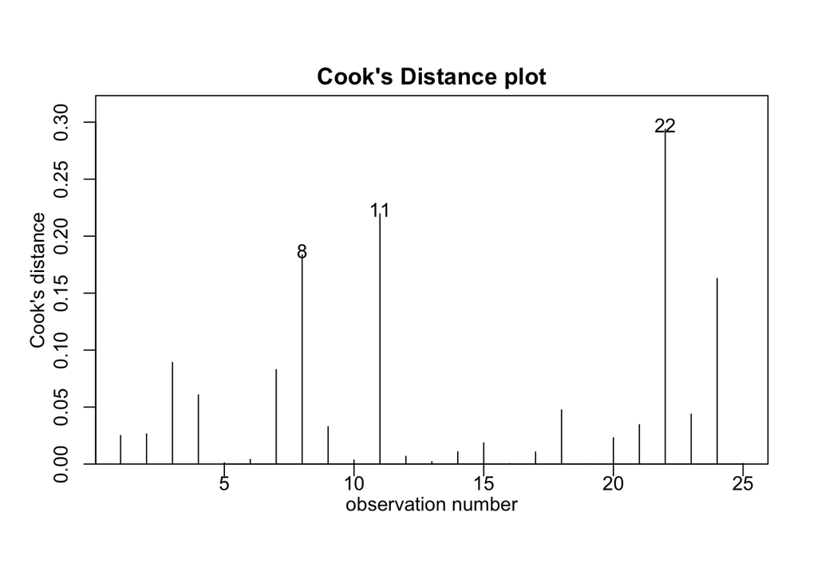

```r
cooks20x(quasar.fit)
```

```r
summary(quasar.fit)
```

```
##
## Call:
## lm(formula = log(RFWidth) ~ flux + line + luminosity + 1, data = quasar.df)
##
## Residuals:
##        Min         1Q     Median         3Q        Max
## -0.0104996 -0.0046296  0.0004234  0.0041729  0.0117130
##
## Coefficients:
##               Estimate Std. Error t value Pr(>|t|)
## (Intercept) -29.798200   0.670812  -44.42   <2e-16 ***
## flux          0.813582   0.012230   66.53   <2e-16 ***
## line          1.508487   0.011015  136.95   <2e-16 ***
## luminosity    0.925750   0.002688  344.41   <2e-16 ***
## ---
## Signif. codes:  0 '***' 0.001 '**' 0.01 '*' 0.05 '.' 0.1 ' ' 1
##
## Residual standard error: 0.006673 on 21 degrees of freedom
## Multiple R-squared:  0.9998, Adjusted R-squared:  0.9998
## F-statistic: 4.083e+04 on 3 and 21 DF,  p-value: < 2.2e-16
```

The pairwise plot of the variables showed that modeling the log of `RFWidth` is appropriate and relationships between the variables appeared to be linear. All linear submodels were fitted and the one with lowest AICc was chosen.

The residual plot was fine with extremely small residuals and constant scatter around zero, the normality assumptions were satisfied and there were no unduly influential points. All model assumption were satisfied.

Our final model is:

$$log(RFWidth) = \beta_0 + \beta_1 \times flux_i + \beta_2 \times line_i + \beta_3 \times luminosity_i + \epsilon_i$$
Where $\epsilon_i \sim iid \space N(0, \sigma^2)$

Our model explained near all of the variability in the logged `RFWidth` values.

## Executive Summary

```r
# Backtransform
round(exp(confint(quasar.fit)), 3)
```

```
##             2.5 % 97.5 %
## (Intercept) 0.000  0.000
## flux        2.199  2.314
## line        4.418  4.625
## luminosity  2.510  2.538
```

```r
100 * (exp(confint(quasar.fit)) - 1)
```

```
##                 2.5 %    97.5 %
## (Intercept) -100.0000 -100.0000
## flux         119.9322  131.4087
## line         341.7526  362.4621
## luminosity   150.9691  153.7907
```

We were interested in modeling `RFWidth` using other variables measured. We found that modeling the log of `RFWidth` was appropriate in this situation. We found that `flux`, `line` and `luminosity` were the most important variables for explaining the log of `RFWidth`.

We estimate that on average, if other parameters are constant, each additional unit of:

- `flux` results in an increase of `RFWidth` by between 120% to 131%,
- `line` flux results in an increase of `RFWidth` by between 342% to 362%,
- `luminosity` results in an increase of `RFWidth` by between 151% to 154%.

## References

Burnham, K. P. and Anderson, D. R (2002) Model selection and multimodel inference: a practical information-theoretic approach. 2nd ed. New York, Springer-Verlag.